# week_07_binary_classification_with_logistic_regression_space_shuttle

### Introduction to logistic regression

Regression is concerned with predicting a continuous response. Classification on the other hand, is interested with classifying a categorical variable. Binary classification is focused on classifying an outcome into one of two possible categories. This notebook introduces binary classification with logistic regression, a type of generalized linear model (GLM). It stress the **similarities** with and **key** difference with Linear Models.

Binary classification with logistic regression is introduced in this notebook using a real data example that had serious consequences. We will work the Space Shuttle Challenger data set. If you are not familiar with Space Shuttle Challenger, the vehicle exploded mid launch on a cold January morning in 1986 due to an O-ring failure. All 7 astronauts on board died.

A data set exists that consists of previous O-ring damage events, as well as the ambient (outside) air temperature. In this notebook, we will introduce logistic regression mostly focusing on fitting the model and predicting the failure probability.

## Import modules

```python
import numpy as np
import pandas as pd
import matplotlib.pyplot as plt

import seaborn as sns
```

We will fit the model using the `statsmodels` formula interface.

```python
import statsmodels.formula.api as smf
```

## Read in the data

We will use the data set prepared for the "Bayesian Methods for Hackers" book, which is an excellent introduction to Bayesian modeling in Python. Please see the book's Github page if you would like to an introduction to Bayesian data analysis. You are not required to read this book though! As far as this notebook is concerned, the book is the source of the data for the example. (The book is great though!)

https://github.com/CamDavidsonPilon/Probabilistic-Programming-and-Bayesian-Methods-for-Hackers

**Please note**: Reading data directly from Github may sometimes act strange. You may need to run the cell below multiple times before the data are read in correctly from Github.

```python
# read in the data

data_url = 'https://raw.githubusercontent.com/CamDavidsonPilon/Probabilistic-Programming-and-Bayesian-Methods-for-Hackers/master/Chapter2_MorePyMC/data/challenger_data.csv'

space_shuttle = pd.read_csv(data_url)
```

### Data preparation

Check the `.info()` method and display the `.head()` and `.tail()` of the data set.

```python
space_shuttle.info()
```

```
<class 'pandas.core.frame.DataFrame'>
RangeIndex: 25 entries, 0 to 24
Data columns (total 3 columns):
 #   Column           Non-Null Count  Dtype
---  ------           --------------  -----
 0   Date             25 non-null     object
 1   Temperature      25 non-null     int64
 2   Damage Incident  24 non-null     object
dtypes: int64(1), object(2)
memory usage: 728.0+ bytes
```

Check the number of unique values.

```python
space_shuttle.nunique()
```

```
Date               25
Temperature        18
Damage Incident     3
dtype: int64
```

Check the number of missing entries.

```python
space_shuttle.isna().sum()
```

```
Date               0
Temperature        0
Damage Incident    1
dtype: int64
```

The MISSING entry occurs near the top of the data.

```python
space_shuttle.head()
```

|  | Date | Temperature | Damage Incident |
| --- | --- | --- | --- |
| 0 | 04/12/1981 | 66 | 0 |
| 1 | 11/12/1981 | 70 | 1 |
| 2 | 3/22/82 | 69 | 0 |
| 3 | 6/27/82 | 80 | NaN |
| 4 | 01/11/1982 | 68 | 0 |

The `Damage Incident` column is the output of interest. Although this is a binary classification problem, we have seen there are 3 unique values. The reason is because the last observation, the accident itself is recorded as text rather than as 0s and 1s.

```python
space_shuttle.tail()
```

|  | Date | Temperature | Damage Incident |
| --- | --- | --- | --- |
| 20 | 10/03/1985 | 79 | 0 |
| 21 | 10/30/85 | 75 | 1 |
| 22 | 11/26/85 | 76 | 0 |
| 23 | 01/12/1986 | 58 | 1 |
| 24 | 1/28/86 | 31 | Challenger Accident |

Alternatively, we can use the `.value_counts()` method to identify the text related value compared to the 0s and 1s for `Damage Incident`.

```python
space_shuttle['Damage Incident'].value_counts()
```

```
Damage Incident
0                      16
1                       7
Challenger Accident     1
Name: count, dtype: int64
```

The last row corresponds to the accident and is labeled as such, rather than 0's and 1's as in the other rows. We will remove this last observation to represent using all data **BEFORE** the accident.

The cell below creates the clean data set by first removing the missing, and then removes the last row. The subsetting is performed by retaining just the 0's and 1's. The cleaned and ready data set is assigned to the `df` object below.

```python
clean_df = space_shuttle.dropna().copy()

df = clean_df.loc[ clean_df['Damage Incident'].isin(['0', '1'])].copy()
```

Let's check the data type associated with each column in the data set.

```python
df.dtypes
```

```
Date               object
Temperature         int64
Damage Incident    object
dtype: object
```

The `Damage Incident` column is a Pandas object type (string), even though it now only contains 0's and 1's:

```python
df['Damage Incident'].value_counts()
```

```
Damage Incident
0    16
1     7
Name: count, dtype: int64
```

Let's convert it to an integer, but assign it to a new column, `y`.

```python
df['y'] = df['Damage Incident'].astype('int64')
```

Even though the `y` and `Damage Incident` columns look to be the same:

```python
df.head()
```

|  | Date | Temperature | Damage Incident | y |
| --- | --- | --- | --- | --- |
| 0 | 04/12/1981 | 66 | 0 | 0 |
| 1 | 11/12/1981 | 70 | 1 | 1 |
| 2 | 3/22/82 | 69 | 0 | 0 |
| 4 | 01/11/1982 | 68 | 0 | 0 |
| 5 | 04/04/1983 | 67 | 0 | 0 |

They are different data types:

```python
df.dtypes
```

```
Date               object
Temperature         int64
Damage Incident    object
y                   int64
dtype: object
```

## Binary outcomes

The response, `y`, is a binary variable. It can take on just one of two possible states. However, we have encoded the variable to be an integer, 0 or 1. The value of 1 corresponds to a failure event, and the value of 0 represents the failure did not happen. The 0/1 encoding allows us to work with any generic binary outcome, such as Hit/Out, Pass/Fail, True/False, Positive/Negative, etc... We can think of it as we observed 1 event or we saw 0 events. The total number of events is the sum of `y` since we are summing together 0's and 1's (a zero does not contribute to the count).

When building a classifier, it is important to consider the empirical or observed proportion of events. We can calculate that simply as the number of events out of the total number of observations. The empirical fraction can be calculated simply using the `.mean()` method since the mean is the sum (of 0's and 1's) divided by the number of observations.

```python
df.y.mean()
```

```
0.30434782608695654
```

To check, let's display the number of rows per unique value of `y` again.

```python
df.y.value_counts()
```

```
y
0    16
1     7
Name: count, dtype: int64
```

As we see above there are 7 events and 16 non-events (non-damage cases in this application). The proportion of observations of the damage event is just the number of events divided by the number of observations (the sum of events and non-events). The value below is identical to the result of `df.y.mean()` given previously.

```python
7 / (7 + 16)
```

```
0.30434782608695654
```

Our goal is study the behavior of the binary outcome with respect to the `Temperature`. So let's visualize this with a scatter plot.

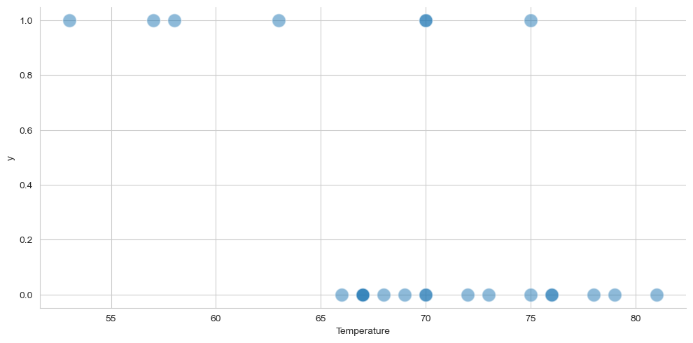

```python
sns.set_style('whitegrid')

sns.relplot(data = df, x='Temperature', y='y', s = 200, alpha = 0.5, aspect=2)

plt.show()
```

The binary outcome can only be 0 or 1. Thus, it can be rather difficult to interpert the output to input relationship in the above figure. However, several trends should stand out. First, no observations of `y=0` occur for `Temperature < 65`. This suggests that the event probability might be very high for lower values of `Temperature`. We have to be careful though since we should also consider the number of observations, but modeling can help us understand the trends within the data.

## Logistic regression

Binary classifiers classify observations into one of two possible categories. With our current applications those states are either fail, `y=1`, or non-failure, `y=0`. Most binary classifiers however do not model or directly classify the outcome. Most binary classifiers predict the probability of the event. We learned in CMPINF 2100 that the classification occurs by comparing the predicted probability to a threshold! However, that is the not the point of the current example. This example dives deeper into the inner workings of the logistic regression.

Predicting or modeling a probability is challenging. We cannot use standard regression techniques that we discussed with the linear model. A probability value is bounded between 0 and 1 (it is a fraction). We cannot have a probability of 2 or a probability of -1.5. Thus, we cannot simply use the linear relationship we introduced with regression:

$$ \mu_n = \beta_0 + \beta_1 \times x_{n} $$

Instead, we need to perform a transformation. Specifically, we will use the *logit* transformation which places the model on the *log odds ratio* rather than the probability directly:

$$ \mathrm{logodds}_n = \beta_0 + \beta_1 \times x_n $$

The log odds ratio is the natural log of the odds ratio. The odds ratio (OR) is defined as the probability divided by 1 minus the probability.:

$$ \mathrm{OR} = \frac{ \mathrm{Probability} }{1 - \mathrm{Probability} } $$

Thus, the model we will work with states that the log-odds ratio is a function of the input.

$$ \log \left(\frac{\mathrm{Probability}_n}{1 - \mathrm{Probability}_n } \right) = \beta_0 + \beta_1 \times x_n$$

The log-odds is also know as the *logit* function. The model is typically named for the inverse or reciprical operation, the **logistic**. Thus, logistic regression gets its name because we are placing a regression model on the log-odds ratio of a binary outcome. The application of logistic regression is for classifying a binary outcome. Therefore, even though logistic regression as the term *regression* in its name it is **not** used for predicting continuous outputs!

### Model fitting: Likelihood and Loss function

Although the formulation is different from linear regression, we will still estimate the coefficients (the intercept and slope) by minimizing the error. The formulation of the **ERROR** is typically referred to as the **LOSS** function. Alternatively, we can view model fitting as maximizing the **LIKELIHOOD**. We learned with linear models that maximizing the likelihood is equivalent to minimizing the sum of squared errors. The same concept applies to classification except the loss function (sum of squared errors) and thus the probability distribution associated with the likelihood are different! Therefore, the Gaussian likelihood is **not** used for binary classification!

Conceptually, we want the loss or error in classification to represent "consistency" between the predicted probabilities and the observed events. If the model predicts a high event probability we hope to observe the event much more frequently than the non-event. Conversely, if the model predicts a low probability we hope to the event is rarely observed. Thus, if the model predicts the event will occur with 80% probability, and yet we routinely do not observe the event, such *misclassifications* will result in poor model performance.

These conceptual goals are represented by the **Bernoulli** distribution. The Bernoulli is a discrete distribution that calculates the probability of the event. The **LIKELIHOOD** is therefore the probability of observing the binary outcome, $y$, **GIVEN** the event probability.

$$ p\left(y \mid \mathrm{Probability}\right) = \mathrm{Bernoulli}\left(y \mid \mathrm{Probability} \right)$$

The Bernoulli distribution is written out as:

$$ \mathrm{Bernoulli}\left(y \mid \mathrm{Probability} \right) = \mathrm{Probability}^{y} \left(1 - \mathrm{Probability}\right)^{1-y}$$

Thus, if we know the event probability, we can calculate how *LIKELY* an event could be.

As discussed in the regression portion, we can assume observations are **conditionally independent** if we know the event probability. All remaining variation is random. Thus, the event probability serves the same role as the **average output** in the regresssion! This allows us to consider numerous observations of the binary outcome. The "complete" likelihood is the product of $N$ conditionally independent observations:

$$ \mathrm{LIKELIHOOD} = \prod_{n=1}^{N} \left( \mathrm{Bernoulli} \left(y_n \mid \mathrm{Probability}_n \right) \right) = \prod_{n=1}^{N} \left( \mathrm{Probability}_{n}^{y_n} \left(1 - \mathrm{Probability}_n\right)^{1-y_n} \right)$$

The event probability is a function of the inputs and includes unknown coefficients that must be estimated by **maximizing the likelihood**. The likelihood is maximized by first applying the natural log which thus provides the **log-likelihood** function as the **sum** of $N$ conditionally independent log-Bernoulli distributions:

$$ \log \left[ \mathrm{LIKELIHOOD} \right] = \sum_{n=1}^{N} \left( \log \left[\mathrm{Bernoulli}\left(y_n \mid \mathrm{Probability}_n \right) \right] \right) $$

Each observation's likelihood can be simplified through the properties of log-arithmetic. The log-likelihood for a single observation is:

$$ \log \left[\mathrm{Bernoulli}\left(y_n \mid \mathrm{Probability}_n \right) \right] = y_n \log \left[\mathrm{Probability}_n \right] + \left(1 - y_n\right) \log \left[ 1 - \mathrm{Probability}_n \right] $$

The above expression might be daunting to look at, but it is conceptual simple to understand. In words the a single observation's log-likelihood is the outcome value (1 or 0) multiplied by the probability of the outcome. Essentially, there are 2 classes - event ($y=1$) or non-event ($y=0$). The probability of each class is $\mathrm{Probability}$ for the event and $1-\mathrm{Probability}$ for the non-event.

The unknown regression coefficients, $\beta$, of the function for the probability, $\mathrm{Probability}=f\left(x, \beta\right)$, are estimated to maximize the log-likelihood.

However, as previously mentioned we could also think of fitting the model by minimizing a loss function. The loss function for binary classification is equal to the **negative** log-likelihood!

$$ \mathrm{LOSS} = - \log \left[ \mathrm{LIKELIHOOD} \right] $$

Binary classification problems give a special name to the loss function. It is known as **cross-entropy**. Thus, fitting the classifier by minimizing the cross-entropy (CE) is the same thing as maximizing the Bernoulli likelihood function!!

$$ \mathrm{CE} = - \sum_{n=1}^{N} \left( \log \left[\mathrm{Bernoulli}\left(y_n \mid \mathrm{Probability}_n \right) \right] \right) = - \sum_{n=1}^{N} \left( y_n \log \left[\mathrm{Probability}_n \right] + \left(1 - y_n\right) \log \left[ 1 - \mathrm{Probability}_n \right] \right)$$

### Link and Inverse link function

The event probability is a function of the input. However, as previously discussed the probability is not modeled directly. Instead the "regression model" is applied to the log-odds ratio. The log-odds ratio or **logit** function is known as the **link** between the Probability and the **linear predictor**. We can recover the Probability by **inverting** the link function. The inverse of the logit is the **logistic** function. The Probability is therefore calculated by applying the logistic function to the log-odds ratio:

$$\mathrm{Probability} = \mathrm{logit}^{-1} \left( \mathrm{logodds} \right) $$

The $\mathrm{logodds}$ is the **linear predictor** which is *linearly* related to the **unknown regression coefficients**.

## Modeling Space Shuttle application

Let's return to modeling the Space Shuttle data. We wish to model the log-odds ratio of the O-ring failure with respect to the ambient temperature. Thus we want a linear predictor of the form shown below:

$$ \log \left(\frac{\mathrm{Probability}}{1 - \mathrm{Probability} } \right) = \beta_0 + \beta_1 \times \mathrm{Temperature}$$

The unknown coefficients we must learn are the intercept and slope applied to the input `Temperature`. However, rather than working `Temperature` directly we will first standardize the variable by subtracting out the mean and dividing by the standard deviation. We are therefore **preprocessing** the input before the model. The cell below manually performs the standardization because it is simple in this application. You are of course free to use `StandardScaler()` and Pipelines to manage the preprocessing for you. However in this notebook we will calculate the standardized temperature manually as a reminder for what `StandardScaler()` is doing.

Create a new column, `x`, which represents the standardized version of the temperature.

```python
df['x'] = (df['Temperature'] - df.Temperature.mean()) / df.Temperature.std()
```

Let's now visualizse the binary outcome with respect to the standardized input. As shown below, the overall figure is similar to what we had previously, except that the input is now negative and positive in the single digits.

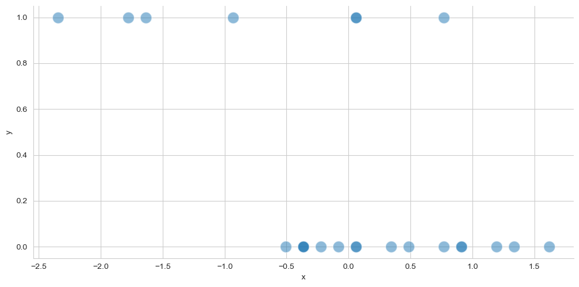

```python
sns.relplot(data = df, x='x', y='y', s = 200, alpha = 0.5, aspect=2)

plt.show()
```

We will use `statsmodels` to fit the logistic regression model. The syntax is very **similar** to the regression case, **except** we need to use a different function comapred to regression. Instead of using `smf.ols()` we must use the `smf.logit()` method. The rest of the syntax is the same. We need to specify the model of interest with the formula interface. The cell initializes the model as a linear relationship between the log-odds ratio and the input.

Remember that the `smf` formula methods require the model to be initialized and then "fit". Notice below that the logistic regression model is the `smf.logit()` method.

```python
model_fit = smf.logit(formula = 'y ~ x', data = df).fit()
```

```
Optimization terminated successfully.
         Current function value: 0.441635
         Iterations 6
```

We can summarize the logistic regression fit using the `.summary()` method just like we did with linear regression. Although this is not a linear model, we can still use p-values and the 95% confidence interval to identify statistical significance!ou should feel comfortable identifying the coefficient estimate and the 95% uncertainty interval on the coefficients.

```python
print( model_fit.summary() )
```

```
                           Logit Regression Results
==============================================================================
Dep. Variable:                      y   No. Observations:                   23
Model:                          Logit   Df Residuals:                       21
Method:                           MLE   Df Model:                            1
Date:                Tue, 31 Jan 2023   Pseudo R-squ.:                  0.2813
Time:                        16:51:42   Log-Likelihood:                -10.158
converged:                       True   LL-Null:                       -14.134
Covariance Type:            nonrobust   LLR p-value:                  0.004804
==============================================================================
                 coef    std err          z      P>|z|      [0.025      0.975]
------------------------------------------------------------------------------
Intercept     -1.1076      0.580     -1.911      0.056      -2.244       0.028
x             -1.6384      0.764     -2.145      0.032      -3.135      -0.141
==============================================================================
```

We can also visualize the coefficient summaries just as we did with regression as a visual alternative to showing statistical significance.

```python
def my_coefplot(model_object, figsize_use=(10, 5)):
    fig, ax = plt.subplots(figsize=figsize_use)

    ax.errorbar(y = model_object.params.index,
               x = model_object.params,
               fmt = 'o', color = 'steelblue', ecolor='steelblue',
               xerr = 2 * model_object.bse,
               elinewidth = 3, ms=10)

    ax.axvline(x = 0, linestyle='--', linewidth=5, color='grey')

    ax.set_xlabel('coefficient value')

    plt.show()
```

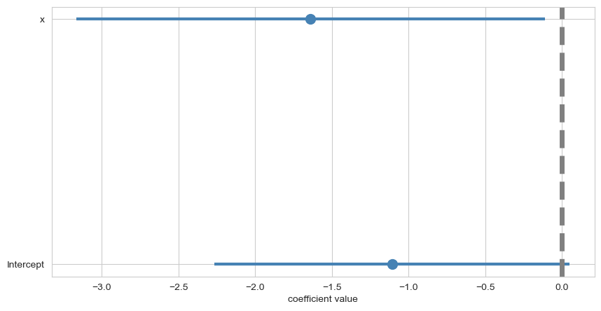

```python
my_coefplot( model_fit )
```

Lastly, we can print the p-values directly if we so desire.

```python
model_fit.pvalues
```

```
Intercept    0.056027
x            0.031956
dtype: float64
```

As we can see the p-value on the input `x` is less than 0.05 and is thus statistically significant at the commonly accepted significance level.

```python
model_fit.pvalues < 0.05
```

```
Intercept    False
x             True
dtype: bool
```

Therefore, the model is confident in the **sign** of the slope multiplying the (standardized) Temperature!

### Prediction

The slope on the `x` variable is negative and thus the log-odds ratio will decrease as the input increases. However, it is very important to remember that the model is on the log-odds ratio and thus the log-odds will decrease on average 1.64 units for every 1 unit increase of the standardized input. Thus, the slope **does not** tell us how the probability will directly change as the input changes. The slopes correspond to changes to the log-odds ratio. However, **if log-odds decreases then probability decreases! If log-odds increases then probability increases!**

Let's make predictions to understand the behavior in the model. Rather than predicting the training set, let's make a very fine resolution grid and predict the event probability (`y=1` with respect to the standardized temperature.

```python
dfviz = pd.DataFrame({'x': np.linspace(-3, 3, num=101)})
```

We can then easily make predictions by assign the `dfviz` argument to the first argument of the `.predict()` method. The prediction result is assigned to the `pred_probability` prediction below.

```python
dfviz['pred_probability'] = model_fit.predict(dfviz)
```

We can now visualize the predicted probability of the event and compare that to the observed binary outcome.

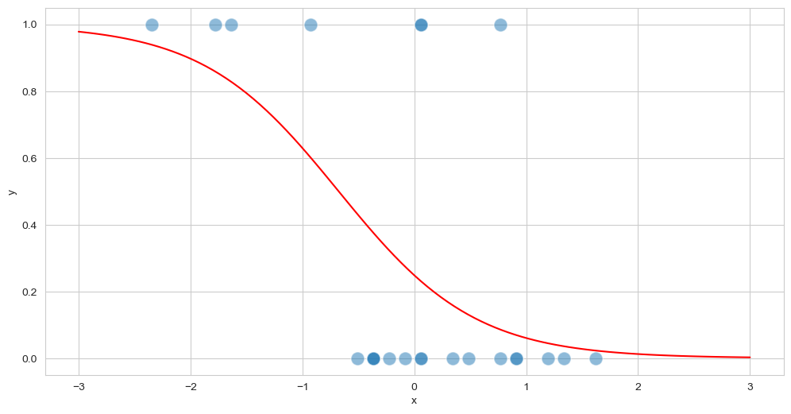

```python
fig, ax = plt.subplots(figsize=(12, 6))

sns.scatterplot(data = df, x='x', y='y', s=150, alpha =0.5)

sns.lineplot(data = dfviz, x='x', y='pred_probability', color = 'r')

plt.show()
```

As shown above, the event probability is largest near the very negative values of the standardized `Temperature`. To help understand the behavior relative to the `Temparture`, let's undo the standardization. The standardized input is **rescaled** by multiplying by the training set standard deviation and then **recentered** by adding in the training set mean.

```python
dfviz['Temperature'] = df.Temperature.std() * dfviz['x'] + df.Temperature.mean()
```

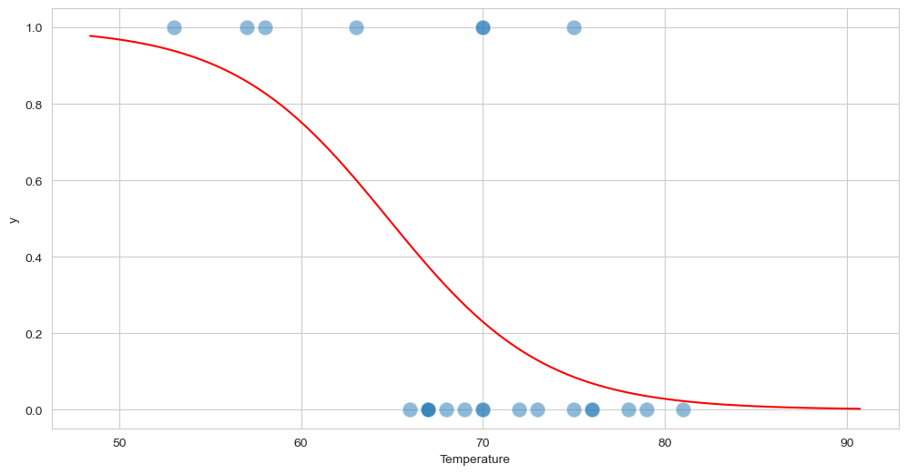

```python
fig, ax = plt.subplots(figsize=(12, 6))

sns.scatterplot(data = df, x='Temperature', y='y', s=150, alpha =0.5)

sns.lineplot(data = dfviz, x='Temperature', y='pred_probability', color = 'r')

plt.show()
```

As we can see above the failure probability equals roughly 50% when the ambient air temperature is about 65 degrees. This example demonstrates that the failure probability is very high when the ambient air temperature is less than 55 degrees. Unfortunately, the cell below shows the temperature the day of the accident was only 31 degrees. That data was well outside the bounds of the training set. But, just based on our simple model's results they should not have launched that day!

```python
space_shuttle.tail(1)
```

|  | Date | Temperature | Damage Incident |
| --- | --- | --- | --- |
| 24 | 1/28/86 | 31 | Challenger Accident |

Adding the Temperature on the day of the accident to the previous plot makes it even more striking that they should not have launched. It reveals just how far away from the training set that observation truly was.

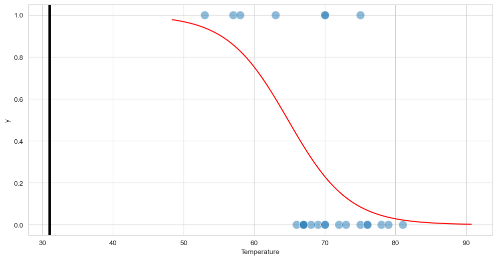

```python
fig, ax = plt.subplots(figsize=(12, 6))

sns.scatterplot(data = df, x='Temperature', y='y', s=150, alpha =0.5, ax=ax)

sns.lineplot(data = dfviz, x='Temperature', y='pred_probability', color = 'r', ax=ax)

ax.axvline( x = clean_df.iloc[-1, :].Temperature, color = 'black', linewidth = 3.5)

plt.show()
```

### What not to do...

We discussed several times in CMPINF 2100 that we should **NEVER** use a regression model for binary classification. We might be tempted to do so because the output has been *encoded* as 0 or 1. However, regression assumes a **Gaussian** Likelihood. The regression problem "thinks" the outcome can be **any** continuous number. A Gaussian is **not** appropriate when the output is binary!

Let's fit such a model just to show how it leads to incorrect interpretations. No warnings are provided when we call `smf.ols()`. The `smf.ols()` function does **not realize** it is working on a binary classification problem! All it knows is that the output is a numeric variable!

```python
wrong_fit = smf.ols(formula = 'y ~ x', data = df).fit()
```

```python
print( wrong_fit.summary() )
```

```
                            OLS Regression Results
==============================================================================
Dep. Variable:                      y   R-squared:                       0.314
Model:                            OLS   Adj. R-squared:                  0.282
Method:                 Least Squares   F-statistic:                     9.630
Date:                Tue, 31 Jan 2023   Prob (F-statistic):            0.00538
Time:                        17:02:26   Log-Likelihood:                -10.441
No. Observations:                  23   AIC:                             24.88
Df Residuals:                      21   BIC:                             27.15
Df Model:                           1
Covariance Type:            nonrobust
==============================================================================
                 coef    std err          t      P>|t|      [0.025      0.975]
------------------------------------------------------------------------------
Intercept      0.3043      0.083      3.661      0.001       0.131       0.477
x             -0.2638      0.085     -3.103      0.005      -0.441      -0.087
==============================================================================
Omnibus:                        4.037   Durbin-Watson:                   1.811
Prob(Omnibus):                  0.133   Jarque-Bera (JB):                3.150
Skew:                           0.903   Prob(JB):                        0.207
Kurtosis:                       2.836   Cond. No.                         1.02
==============================================================================

Notes:
[1] Standard Errors assume that the covariance matrix of the errors is correctly specified.
```

The slope on the standardized temperature, `x`, is statistically significantly negative. Therefore, statistical significance will **not** tell you you made a mistake!

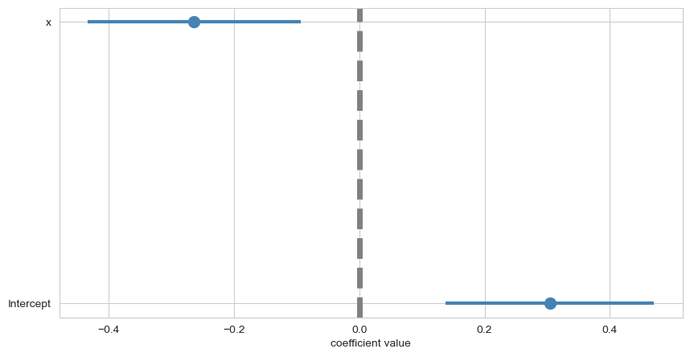

```python
my_coefplot( wrong_fit )
```

Let's visualize the predictions from this wrong model. The cells below extract the predictive trend and **both** types of uncertainty intervals.

```python
wrong_fit_predictions = wrong_fit.get_prediction( dfviz.copy() )
```

```python
wrong_fit_viz_summary = wrong_fit_predictions.summary_frame()
```

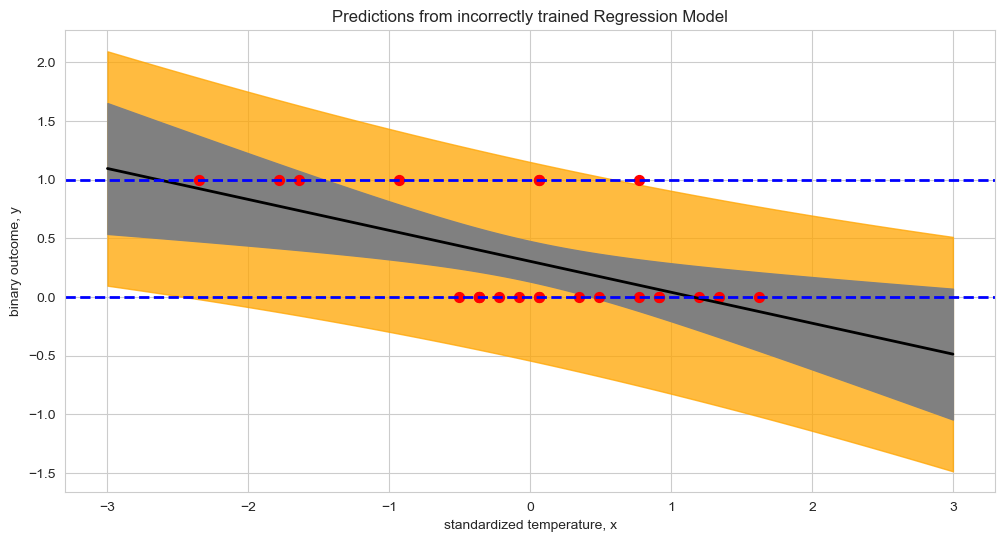

```python
fig, ax = plt.subplots(figsize=(12, 6))

# prediction interval
ax.fill_between(dfviz.x,
                wrong_fit_viz_summary.obs_ci_lower,
                wrong_fit_viz_summary.obs_ci_upper,
                facecolor='orange', alpha=0.75, edgecolor='orange')

# confidence interval
ax.fill_between(dfviz.x,
                wrong_fit_viz_summary.mean_ci_lower,
                wrong_fit_viz_summary.mean_ci_upper,
                facecolor='grey', alpha=1., edgecolor='grey')

# trend
ax.plot(dfviz.x, wrong_fit_viz_summary['mean'], color='black', linewidth=2)

# refernece horizontal lines for this plot specifically
ax.axhline(y=0, color='blue', linestyle='--', linewidth=2)
ax.axhline(y=1, color='blue', linestyle='--', linewidth=2)

# training data
ax.scatter(df.x, df.y, color='red', s=50)

# labels
ax.set_xlabel('standardized temperature, x')
ax.set_ylabel('binary outcome, y')
ax.set_title('Predictions from incorrectly trained Regression Model')

plt.show()
```

The **correct** logistic regression model **does not** suffer from such issues. The **logit** transformation **makes sure** the predicted probability is **always** between 0 and 1. The logit transformation (and its inverse the logistic) create an S-shaped curve which causes the predicted probability to come close to but never exceed 1 and come close to but never drop below 0.

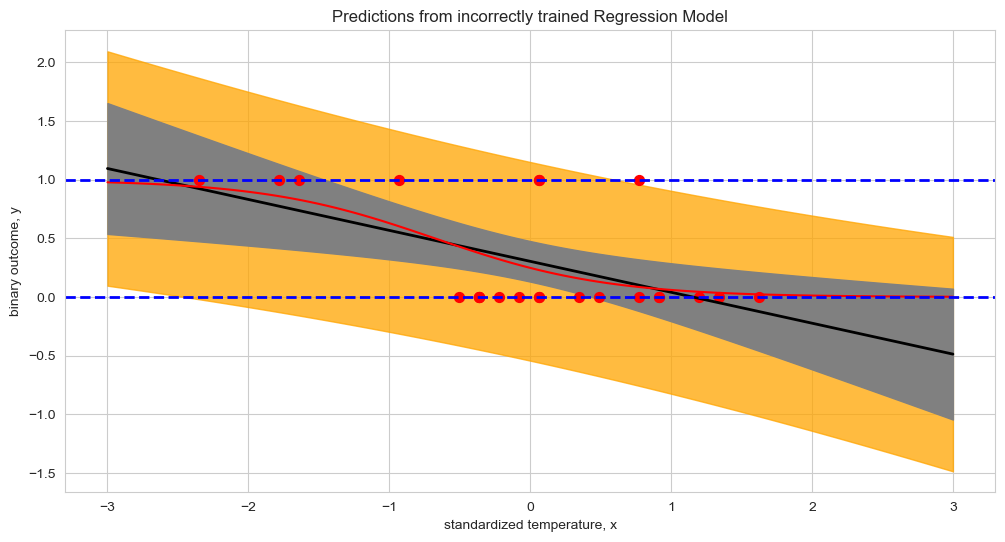

```python
fig, ax = plt.subplots(figsize=(12, 6))

# prediction interval
ax.fill_between(dfviz.x,
                wrong_fit_viz_summary.obs_ci_lower,
                wrong_fit_viz_summary.obs_ci_upper,
                facecolor='orange', alpha=0.75, edgecolor='orange')

# confidence interval
ax.fill_between(dfviz.x,
                wrong_fit_viz_summary.mean_ci_lower,
                wrong_fit_viz_summary.mean_ci_upper,
                facecolor='grey', alpha=1., edgecolor='grey')

# trend
ax.plot(dfviz.x, wrong_fit_viz_summary['mean'], color='black', linewidth=2)

# correct predicted probability from logistic regression!
sns.lineplot(data = dfviz, x='x', y='pred_probability', color = 'r', ax=ax)

# refernece horizontal lines for this plot specifically
ax.axhline(y=0, color='blue', linestyle='--', linewidth=2)
ax.axhline(y=1, color='blue', linestyle='--', linewidth=2)

# training data
ax.scatter(df.x, df.y, color='red', s=50)

# labels
ax.set_xlabel('standardized temperature, x')
ax.set_ylabel('binary outcome, y')
ax.set_title('Predictions from incorrectly trained Regression Model')

plt.show()
```

## Summary

This report demonstrated the two major differences between Linear Models for regression and Logistic Regression models for Classification. It showed that the Gaussian likelihood is **not** appropriate because the output is binary and not continuous. It also showed that the **logit** transformation is critical for ensuring the predicted probability is **bounded** between 0 and 1! Both aspects are critically important in order to properly apply and interpret binary classifiers!